# Ejercicios Capítulo 3. Visualización

### Estéticas

- color o (colour)
- size
- alpha (trasparencia)
- shape (admite hasta 6)

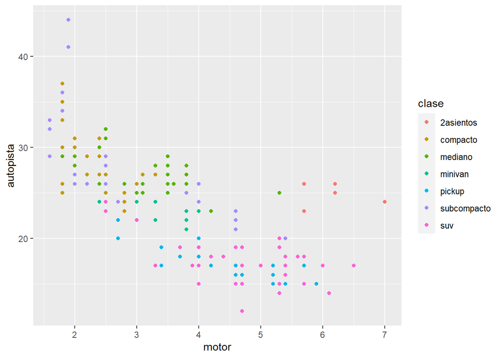

```r
ggplot(data = millas) +
  geom_point(mapping = aes(x = motor, y = autopista, color = clase))
```

Para cambiar la estética del gráfico (todos los puntos de un solo color) pero no agregar información:

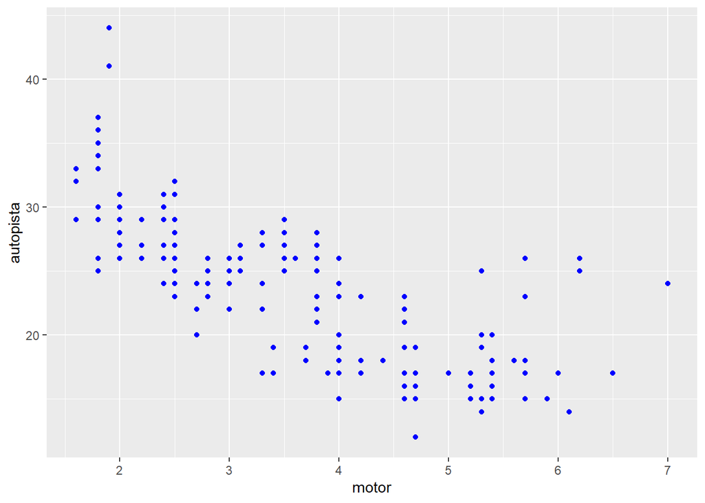

```r
ggplot(data = millas) +
  geom_point(mapping = aes(x = motor, y = autopista), color = "blue")
```

### Ejercicios (3.3.1)

1. ¿Qué no va bien en este código? ¿Por qué hay puntos que no son azules?

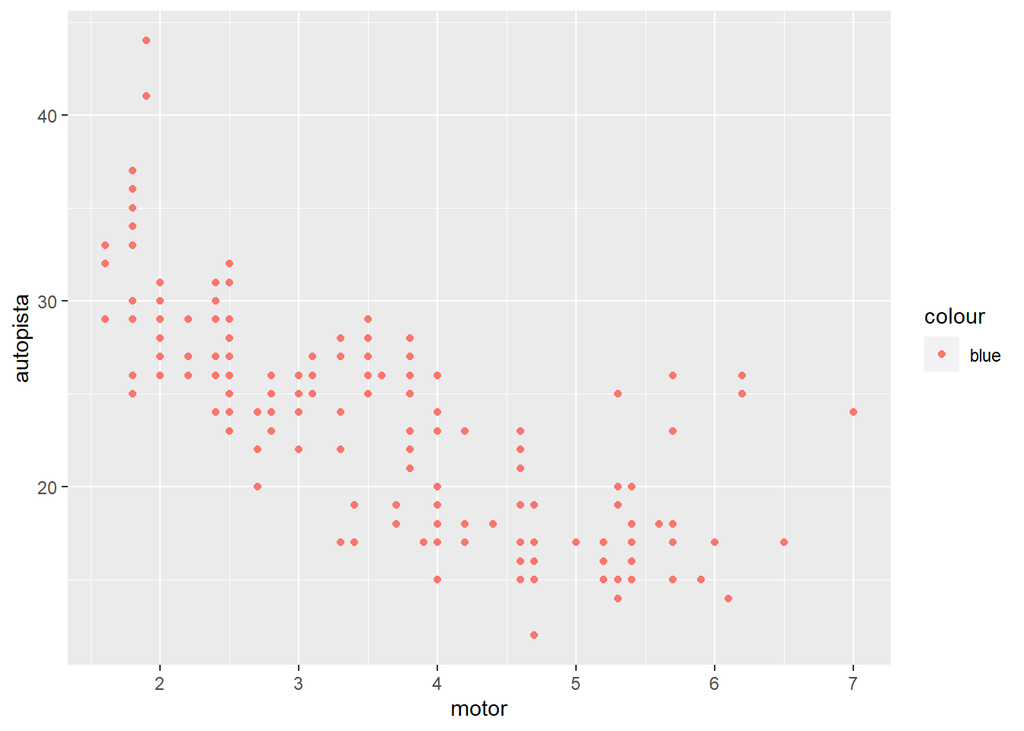

```r
ggplot(data = millas) +
  geom_point(mapping = aes(x = motor, y = autopista, color = "blue"))
```

```r
# Para cambiar la estética de forma manual debe ir fuera de aes()
```

2. ¿Qué variables en millas son categóricas? ¿Qué variables son continuas? (Sugerencia: escribe ?millas para leer la documentación de ayuda para este conjunto de datos). ¿Cómo puedes ver esta información cuando ejecutas millas?

```r
# millas
# bajo el nombre se puede ver el tipo de variable
# <chr> categóricas
# <dbl> continuas
# <int> continuas aunque algunas podrias redefinirse como factores

# Otra opción:
# str(millas)
```

3. Asigna una variable continua a color, size, y shape. ¿Cómo se comportan estas estéticas de manera diferente para variables categóricas y variables continuas?

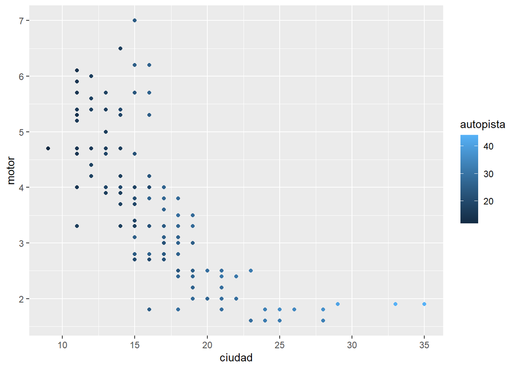

```r
ggplot(data = millas) +
  geom_point(mapping = aes(x = ciudad, y = motor, color = autopista))
```

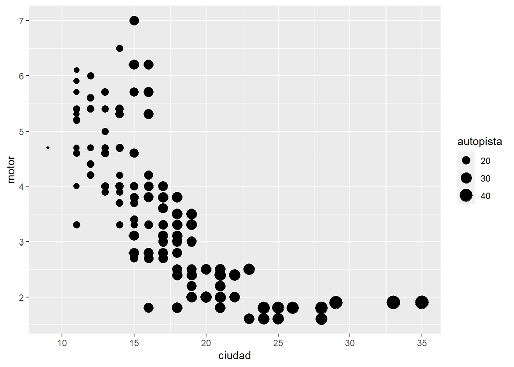

```r
ggplot(data = millas) +
  geom_point(mapping = aes(x = ciudad, y = motor, size = autopista))
```

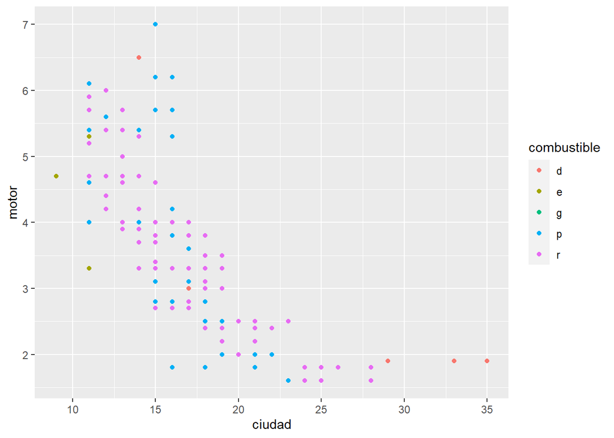

```r
ggplot(data = millas) +
  geom_point(mapping = aes(x = ciudad, y = motor, color = combustible))
```

Para las variables continuas se establecen automaticamente **rangos** de valores de la variable al usar `color` y`size`. Pero `shape` no funciona con variables continuas.

4. ¿Qué ocurre si asignas o mapeas la misma variable a múltiples estéticas?

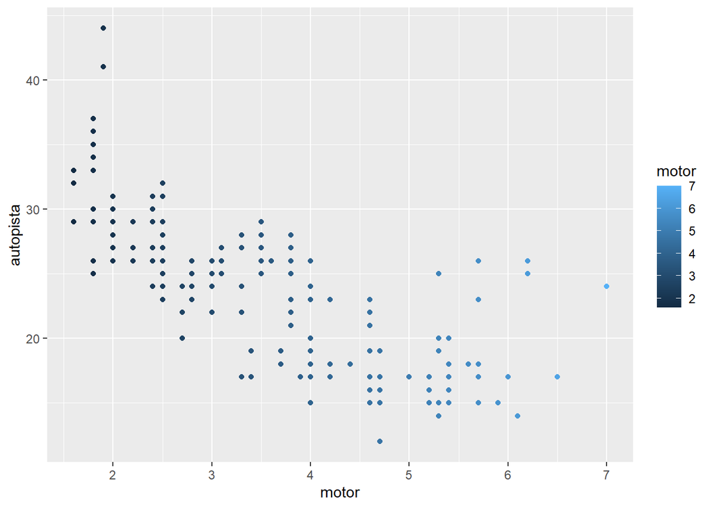

```r
ggplot(data = millas) +
  geom_point(mapping = aes(x = motor, y = autopista, color = motor))
```

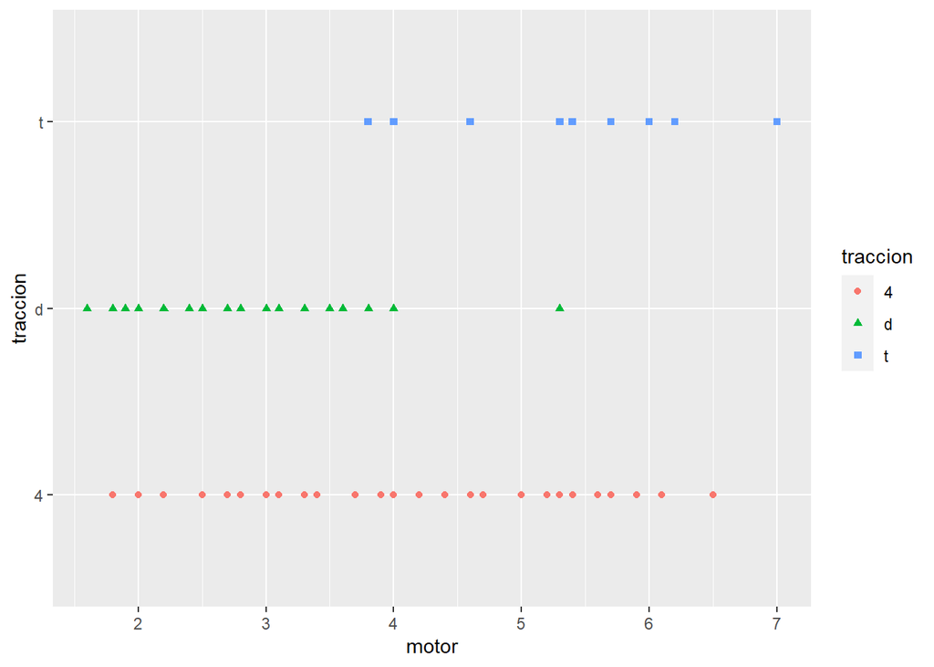

```r
ggplot(data = millas) +
  geom_point(mapping = aes(x = motor, y = traccion, color = traccion, shape = traccion ))
```

Se considera las respectivas acciones en cada estética.

5. ¿Qué hace la estética stroke? ¿Con qué formas trabaja? (Sugerencia: consultar ?geom_point)

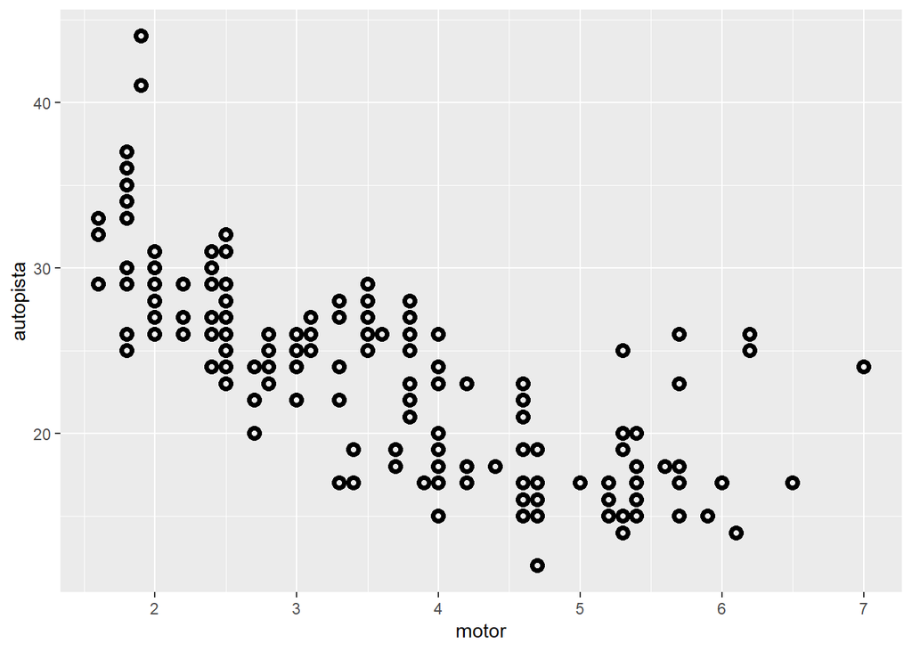

```r
ggplot(data = millas) +
  geom_point(mapping = aes(x = motor, y = autopista), shape = 21, stroke = 2)
```

Trabaja con formas `shape` que tienen un borde y cambia en acho de los bordes.

6. ¿Qué ocurre si se asigna o mapea una estética a algo diferente del nombre de una variable, como aes(color = motor < 5)?

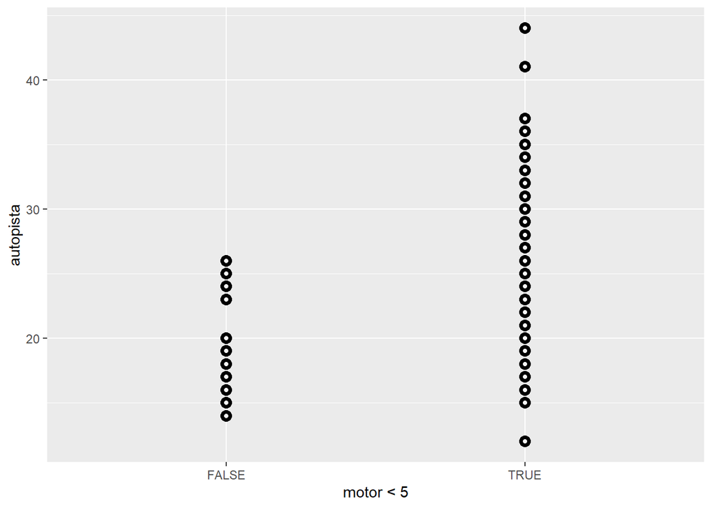

```r
ggplot(data = millas) +
  geom_point(mapping = aes(x = motor < 5, y = autopista), shape = 21, stroke = 2)
```

Si se define por ejemplo `motor < 5` la variable `motor` se redefine como una de tipo binaria y el gráfico lo considera como tal.

### Facetas

- Gráficos separados para categorias de una variable `facet_wrap()`:

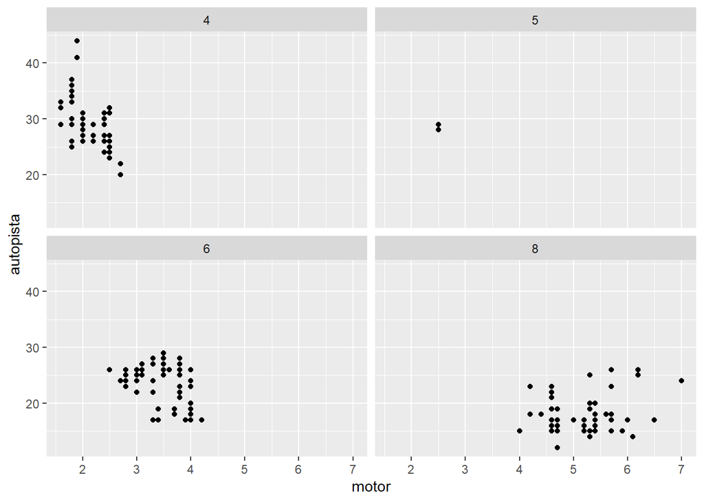

```r
ggplot(data = millas) +
  geom_point(mapping = aes(x = motor, y = autopista)) +
  facet_wrap(~ cilindros)
```

- Graficos separados combinando las categorias de dos variables `facet_grip()`

```r
ggplot(data = millas) +
  geom_point(mapping = aes(x = motor, y = autopista)) +
  facet_grid(traccion ~ cilindros)
```

[output not shown]

- Para no separar en facetas las filas o columnas `facet_grid(. ~ Variable)`

```r
ggplot(data = millas) +
  geom_point(mapping = aes(x = motor, y = autopista)) +
  facet_grid(traccion ~ .)
```

[output not shown]

### Ejercicios 3.5.1

1. ¿Qué ocurre si intentas separar en facetas una variable continua?

Habrá tantos gráficos como valores únicos en la variable continua.

2. ¿Qué significan las celdas vacías que aparecen en el gráfico generado usando `facet_grid(traccion ~ cilindros)`? ¿Cómo se relacionan con este gráfico?

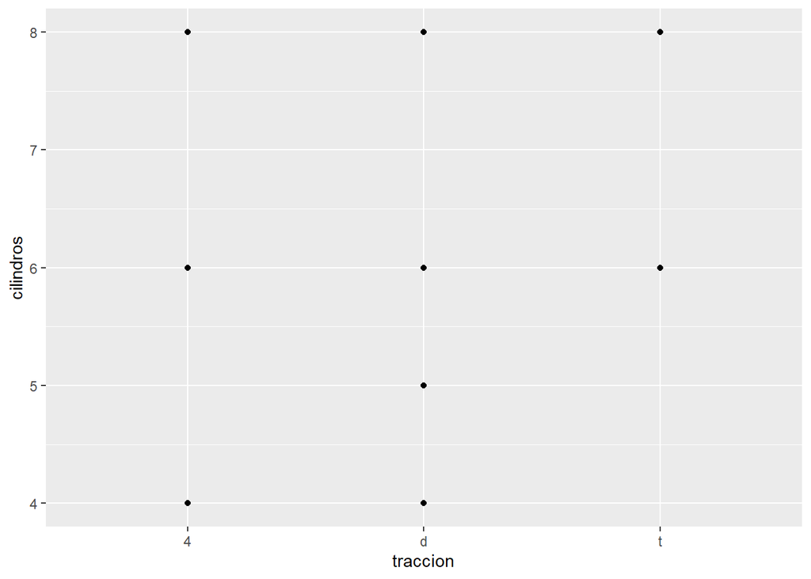

```r
ggplot(data = millas) +
  geom_point(mapping = aes(x = traccion, y = cilindros))
```

```r
ggplot(data = millas) +
  geom_point(mapping = aes(x = motor, y = autopista)) +
  facet_grid(traccion ~ cilindros)
```

[output not shown]

El gráfico por facetas no tiene puntos porque no hay observaciones con esas dos características simultaneamente y esa es la relacion entre los dos gráficos.

3. ¿Qué gráfica el siguiente código? ¿Qué hace . ?

```r
ggplot(data = millas) +
  geom_point(mapping = aes(x = motor, y = autopista)) +
  facet_grid(traccion ~ .)
```

[output not shown]

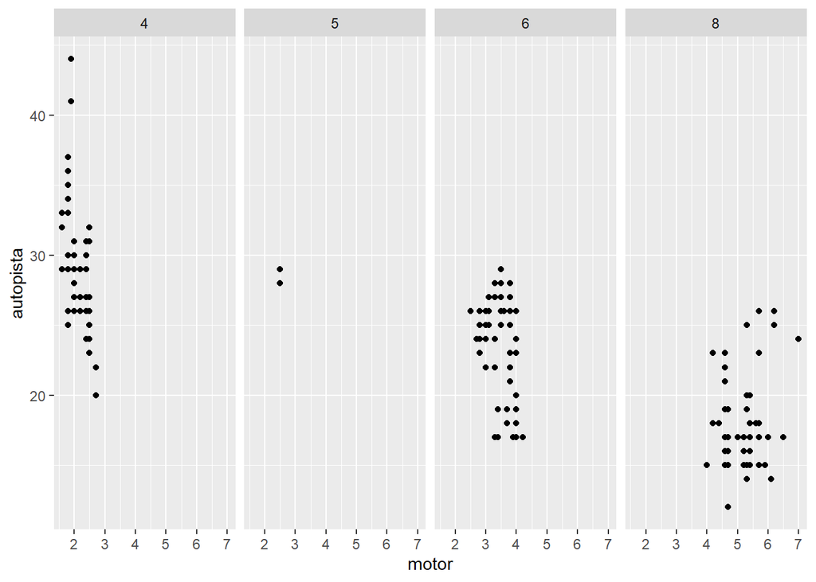

```r
ggplot(data = millas) +
  geom_point(mapping = aes(x = motor, y = autopista)) +
  facet_grid(. ~ cilindros)
```

Hace un gráfico de dispersión del tamaño de motor versus el rendimiento en autopista. El `.` define si las facetas se colocarán en el eje x (`. ~ variable`) o en el eje y (`variable ~ .`).

4. Mira de nuevo el primer gráfico en facetas presentado en esta sección:

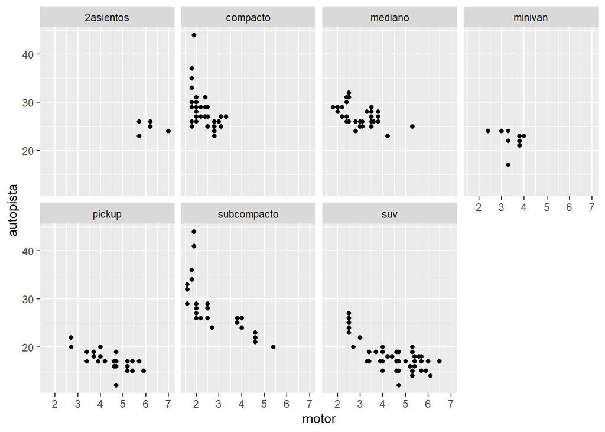

```r
ggplot(data = millas) +
  geom_point(mapping = aes(x = motor, y = autopista)) +
  facet_wrap(~ clase, nrow = 2)
```

¿Cuáles son las ventajas de separar en facetas en lugar de aplicar una estética de color? ¿Cuáles son las desventajas? ¿Cómo cambiaría este balance si tuvieras un conjunto de datos más grande?

Se puede identificar si la relación entre las variables es diferente dentro de cada categoría de la variable que se usa en facetas. Se tiene una mejor visualización.

Con un conjunto de datos más grande podría haber gráficos con pocas observaciones y otros muy cargados que no permitan diferenciar nada relevante.

5. Lee ?facet_wrap. ¿Qué hace nrow? ¿Qué hace ncol? ¿Qué otras opciones controlan el diseño de los paneles individuales? ¿Por qué facet_grid() no tiene argumentos nrow y ncol?

Definen número de filas y de columnas.

Otras opciones para controlar el diseño de los paneles individuales: `labeller`, `strip.position`, `dir`

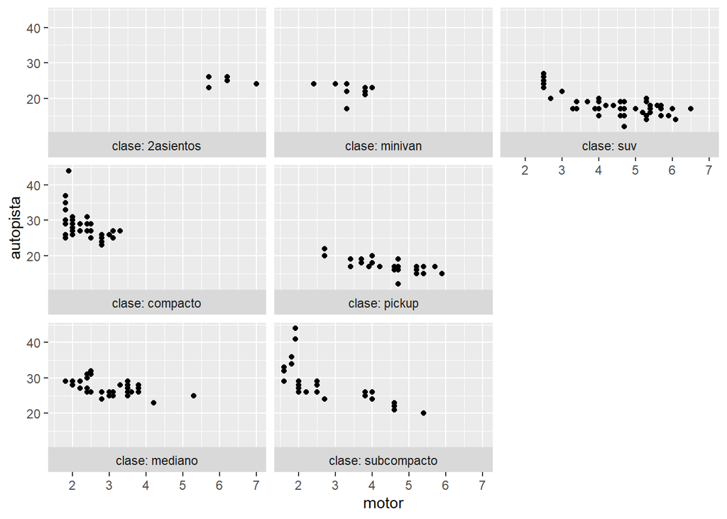

```r
ggplot(data = millas) +
  geom_point(mapping = aes(x = motor, y = autopista)) +
  facet_wrap(~clase, labeller = "label_both", strip.position = "bottom", dir = "v")
```

Porque `facet_grid()` combina las categorías de las dos variables.

6. Cuando usas facet_grid(), generalmente deberías poner la variable con un mayor número de niveles únicos en las columnas. ¿Por qué?

Las pantallas son más anchas que altas (?). Los gráficos se visualizan mejor.

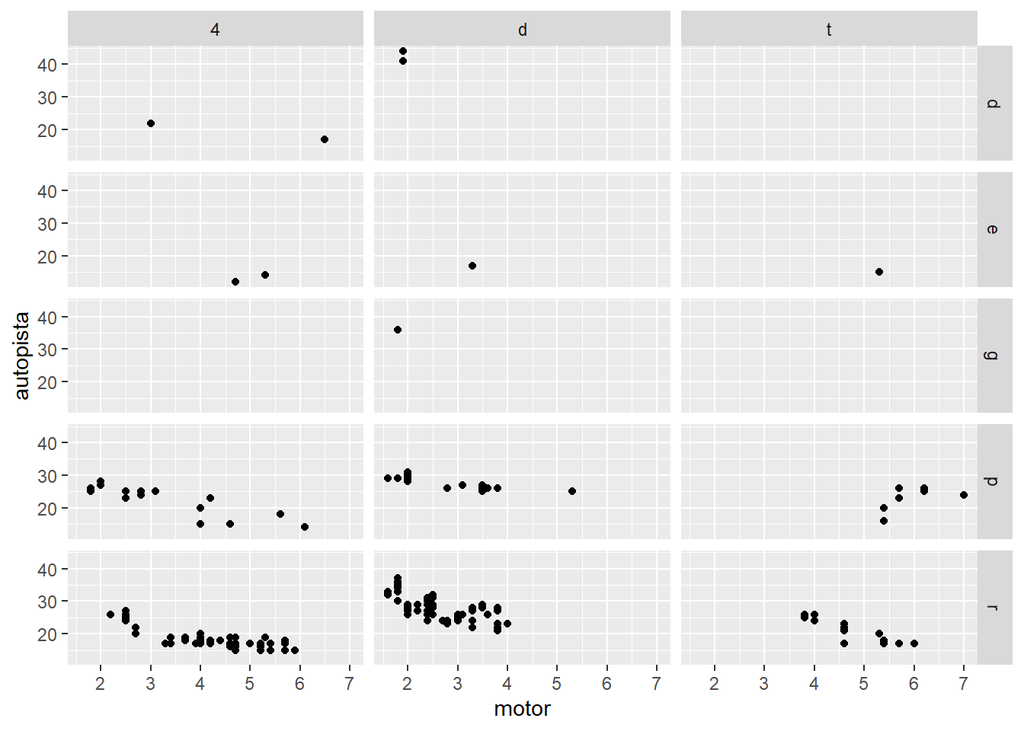

```r
ggplot(data = millas) +
  geom_point(mapping = aes(x = motor, y = autopista)) +
  facet_grid(combustible ~ traccion)
```

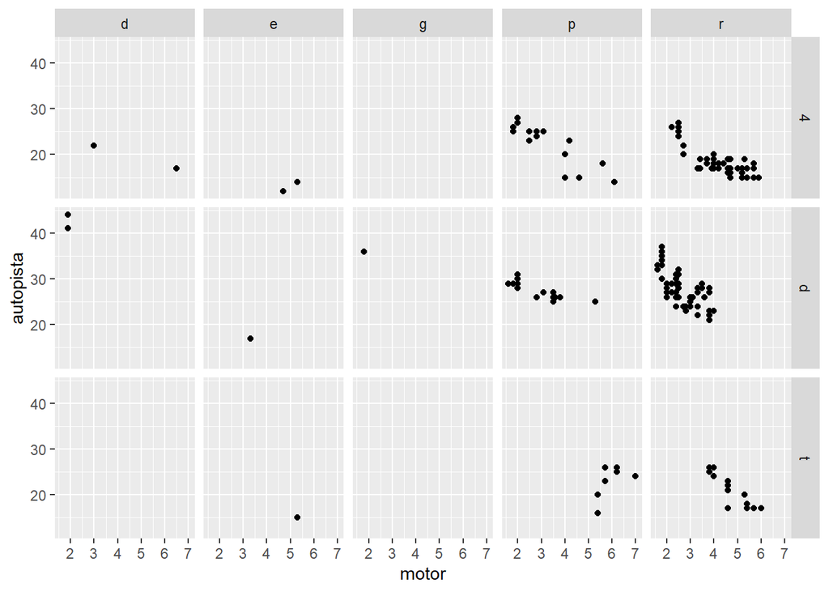

```r
ggplot(data = millas) +
  geom_point(mapping = aes(x = motor, y = autopista)) +
  facet_grid(traccion ~ combustible)
```

### geom

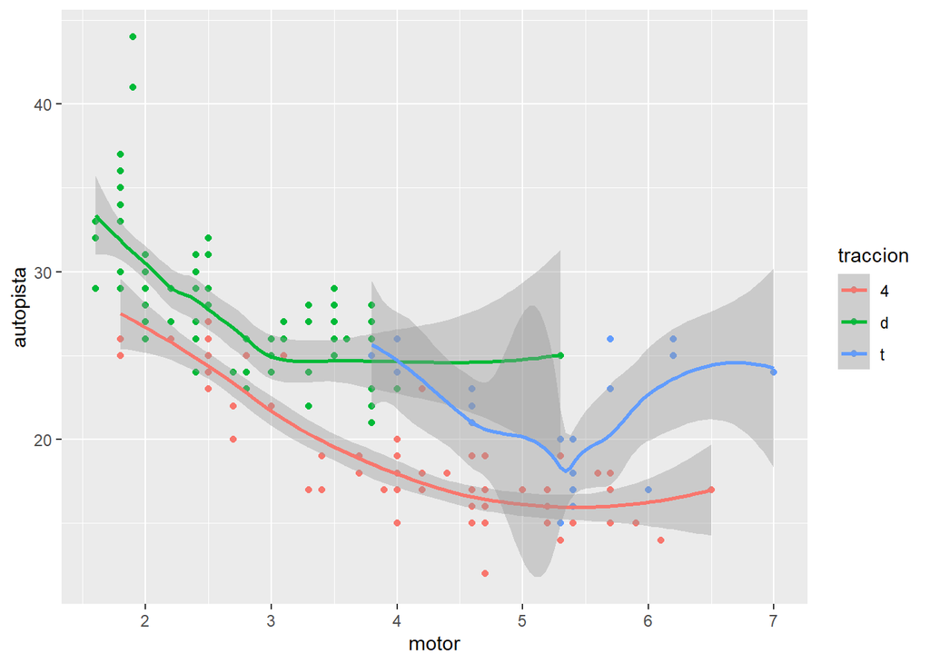

```r
ggplot(data = millas) +
  geom_point(mapping = aes(x = motor, y = autopista, color = traccion)) +
  geom_smooth(mapping = aes (x = motor, y = autopista, color = traccion))
```

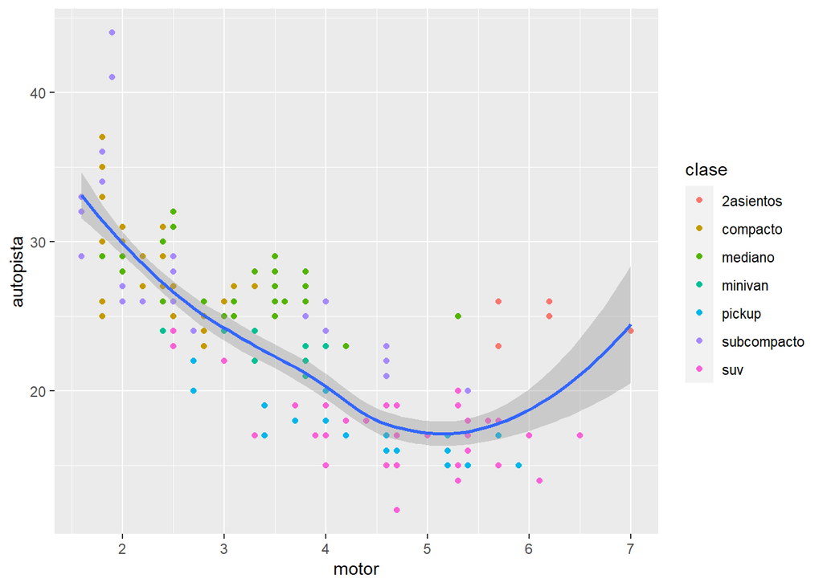

```r
ggplot(data = millas, mapping = aes(x = motor, y = autopista)) +
  geom_point(mapping = aes(color = clase)) +
  geom_smooth()
```

### Ejercicios (3.6.1)

1. ¿Qué geom usarías para generar un gráfico de líneas? ¿Y para un diagrama de caja? ¿Y para un histograma? ¿Y para un gráfico de área?
- Lineas: `geom_line()`
- Gráficos de caja: `geom_boxplot()`

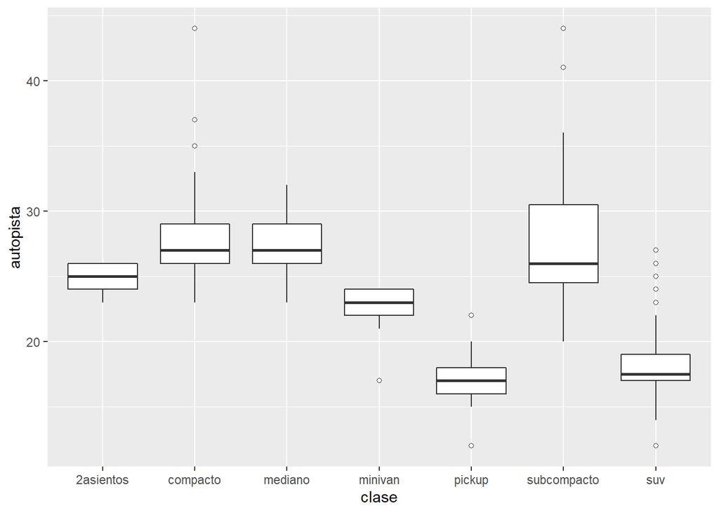

```r
ggplot(data = millas, mapping =aes(x = clase, y = autopista)) +
  geom_boxplot(outlier.shape = 21 )
```

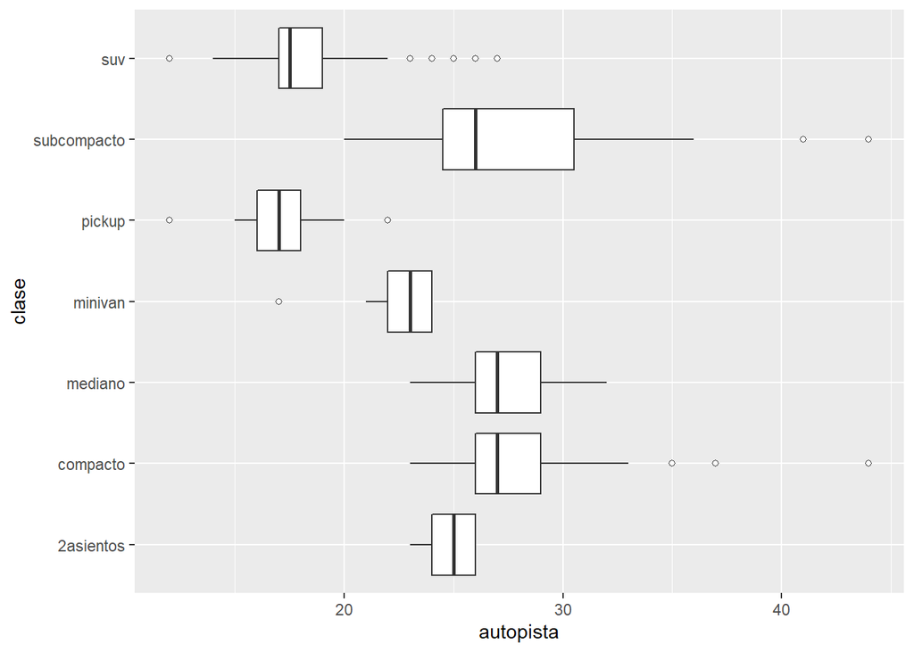

```r
#para girarlo:
ggplot(data = millas, mapping =aes(y = clase, x = autopista)) +
  geom_boxplot(outlier.shape = 21 )
```

** AQUI tengo una duda con los boxplot de dos variables continuas usando group**

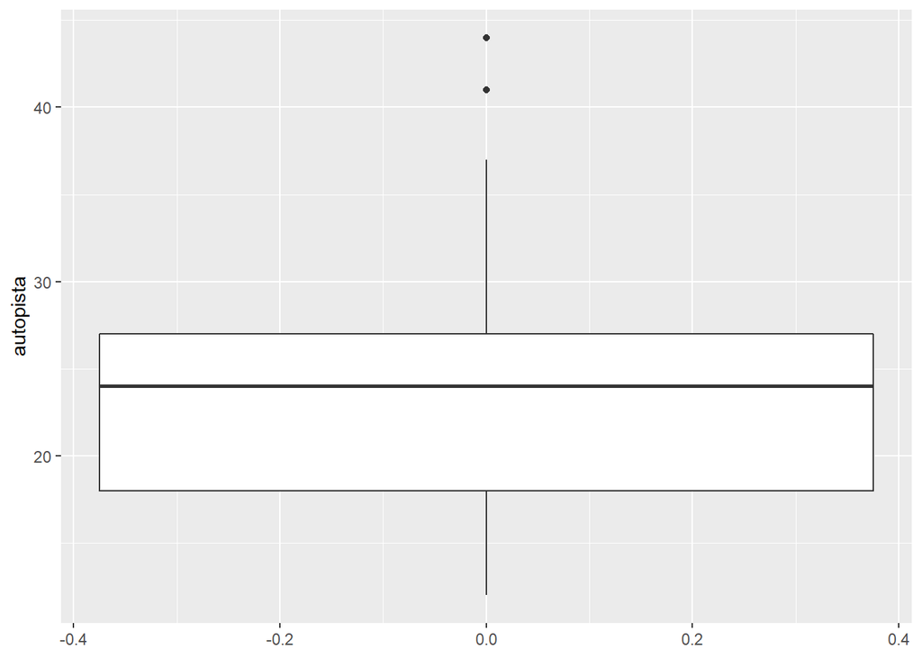

```r
ggplot(data = millas, mapping =aes(y = autopista)) + geom_boxplot() # vertical
```

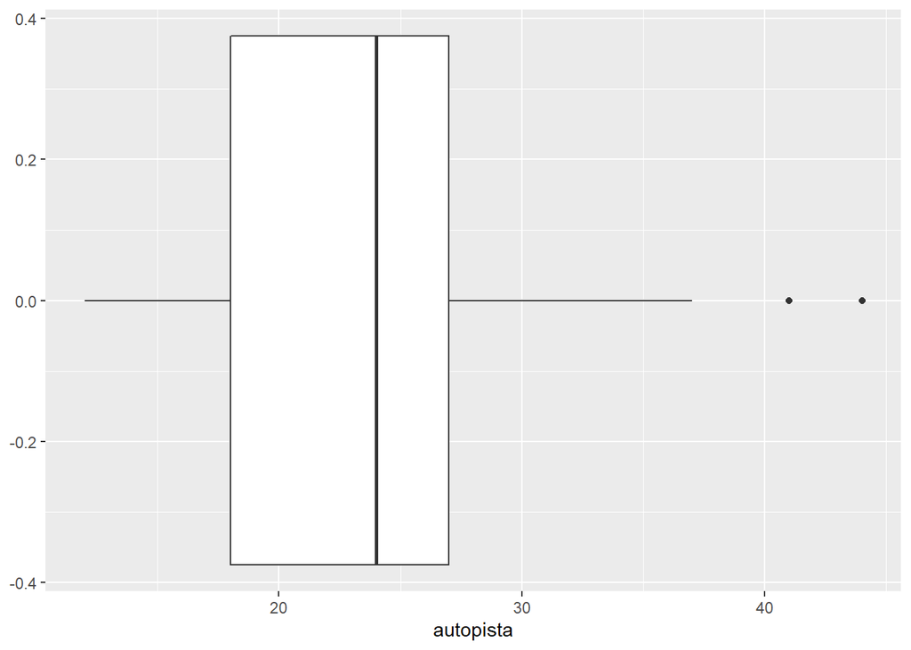

```r
ggplot(data = millas, mapping =aes(x = autopista)) + geom_boxplot() # horizontal
```

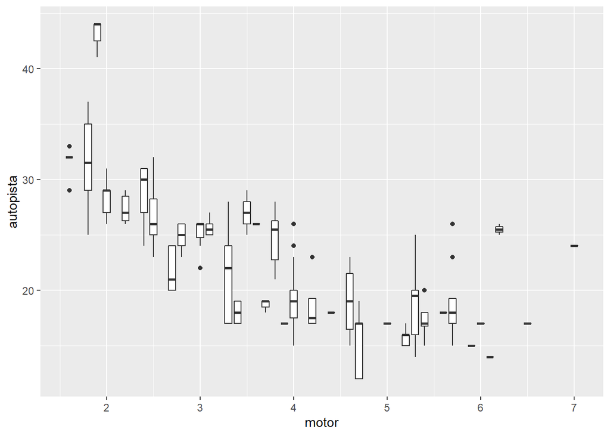

```r
ggplot(data = millas, mapping =aes(y = autopista, x = motor)) + geom_boxplot(aes(group = motor)) # esto "categoriza" la variable continua que esta en x ?
```

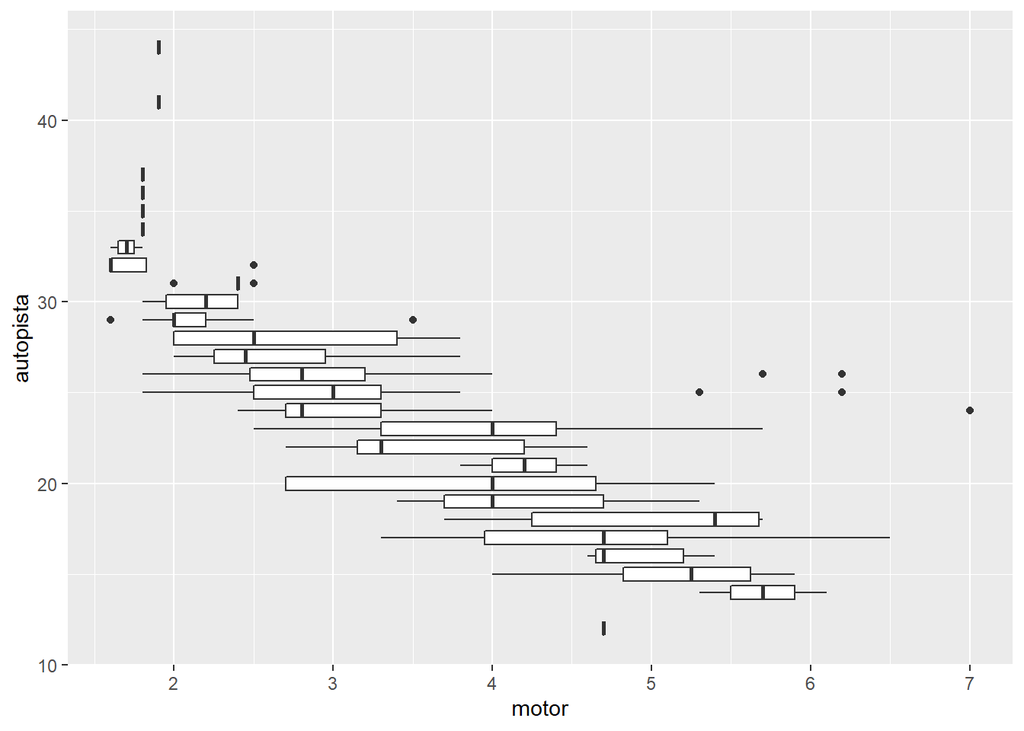

```r
ggplot(data = millas, mapping =aes(y = autopista, x = motor)) + geom_boxplot(aes(group = autopista)) # este para mi no tiene sentido porque quiero que y (la que se gráfica) sea autopista
```

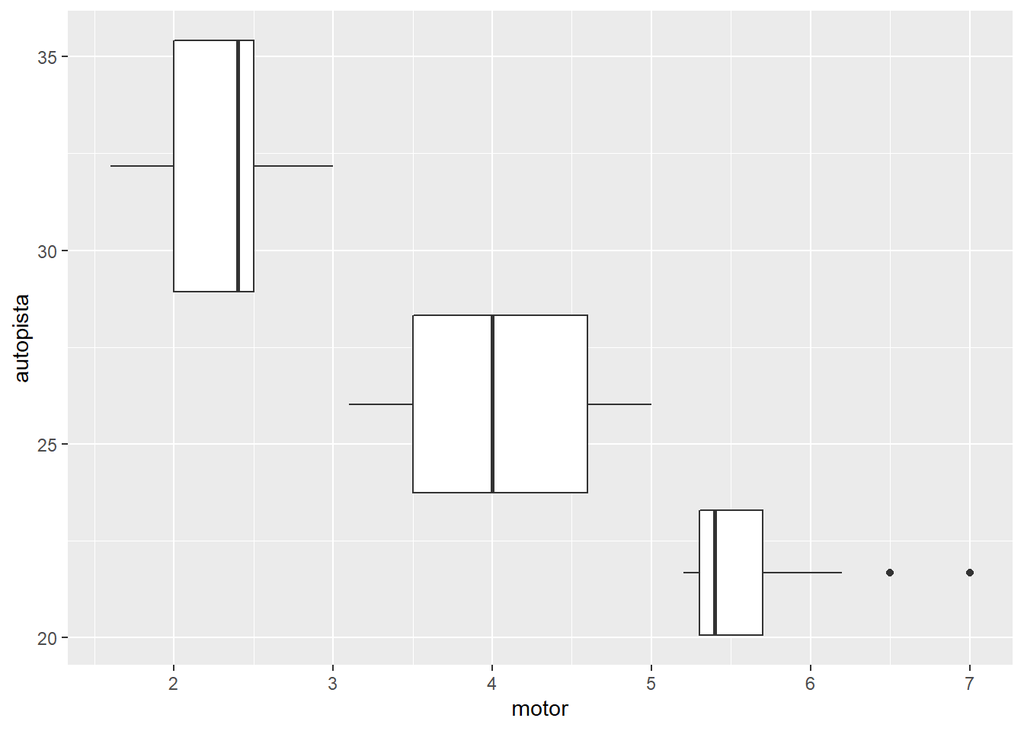

```r
ggplot(data = millas, mapping =aes(y = autopista, x = motor)) +
  geom_boxplot(aes(group = cut_width(motor,2))) # por qué salen al revés? quiero graficar y :(
```

- Histograma: `geom_histogram()`

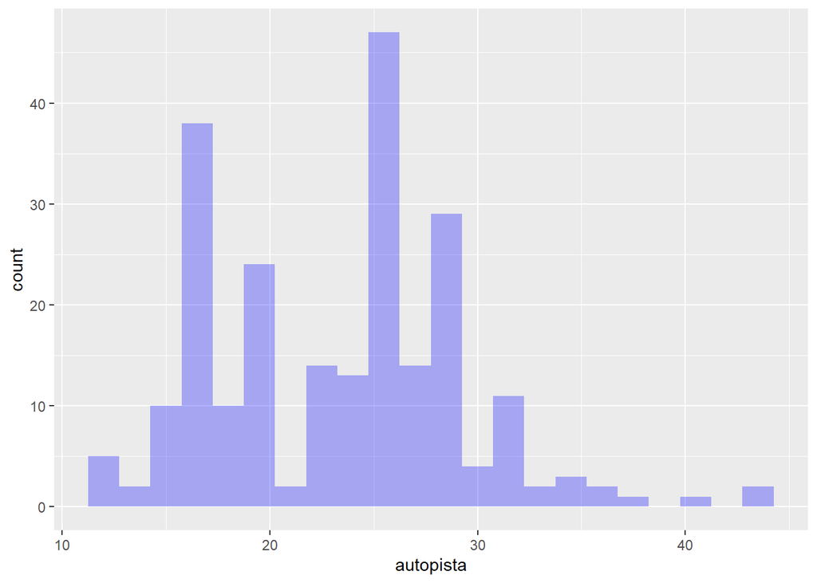

```r
ggplot(data = millas, mapping = aes(x = autopista)) +
  geom_histogram(binwidth = 1.5, alpha = 0.3, fill = "blue")
```